# Tutorial 8.2: Multiple regression on the FEV dataset

As an exercise on multiple regression, we will analyse the FEV dataset.

# 1 The FEV dataset

The FEV, which is an acronym for forced expiratory volume, is a measure of how much air a person can exhale (in liters) during a forced breath. In this dataset, the FEV of 606 children, between the ages of 6 and 17, were measured. The dataset also provides additional information on these children: their `age`, their `height`, their `gender` and, most importantly, whether the child is a smoker or a non-smoker.

The goal of this experiment was to find out whether or not smoking has an effect on the FEV of children.

# 2 Load the required libraries

```r
library(tidyverse)
library(GGally)
```

# 3 Import the data

```r
fev <- read_tsv("https://raw.githubusercontent.com/GTPB/PSLS20/master/data/fev.txt")
head(fev)
```

```
## # A tibble: 6 x 5
##     age   fev height gender smoking
##   <dbl> <dbl>  <dbl> <chr>    <dbl>
## 1     9  1.71   57   f            0
## 2     8  1.72   67.5 f            0
## 3     7  1.72   54.5 f            0
## 4     9  1.56   53   m            0
## 5     9  1.90   57   m            0
## 6     8  2.34   61   f            0
```

# 4 Data tidying

There are a few things in the formatting of the data that can be improved upon:

1. Both the `gender` and `smoking` should be transformed to factors.
2. The `height` variable is written in inches. Let’s add a new column, `height_cm`, with the values converted to centimeters.

```r
fev <- fev %>%
  mutate(gender = as.factor(gender)) %>%
  mutate(smoking = as.factor(smoking)) %>%
  mutate(height_cm = height*2.54)

head(fev)
```

```
## # A tibble: 6 x 6
##     age   fev height gender smoking height_cm
##   <dbl> <dbl>  <dbl> <fct>  <fct>       <dbl>
## 1     9  1.71   57   f      0            145.
## 2     8  1.72   67.5 f      0            171.
## 3     7  1.72   54.5 f      0            138.
## 4     9  1.56   53   m      0            135.
## 5     9  1.90   57   m      0            145.
## 6     8  2.34   61   f      0            155.
```

That’s better!

# 5 Data exploration

Remember the “Data_exploration_FEV.Rmd” exercise? There, we saw that plotting the FEV in function of smoking status only, it appeared that the FEV was higher for smokers. However, if we “corrected” the visualization for a child’s age and/or heigth and/or gender, this completely changed the picture. As such, it is clear that, in order to study the effect of smoking on the FEV, we should account for these other variables in the dataset (commonly referred to as confounders).

First, we can take a lookt at the associations and correlations between the different variables.

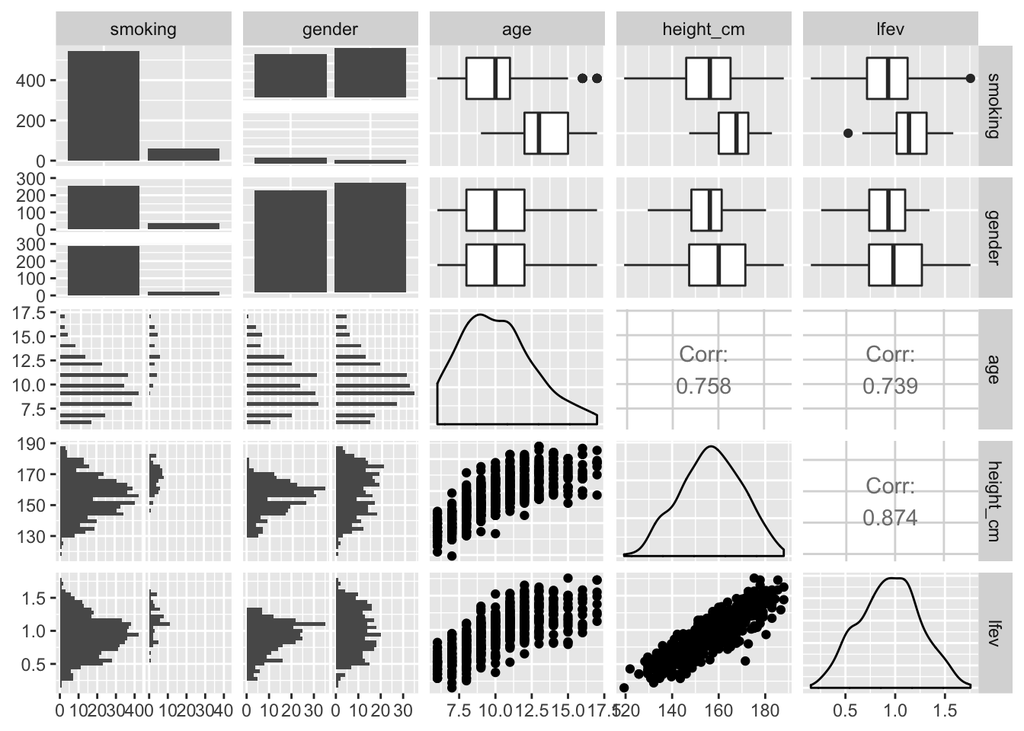

```r
fev %>%
  mutate(lfev=log(fev)) %>%
  dplyr::select(smoking,gender,age,height_cm,lfev) %>%
  ggpairs()
```

We absorve some very clear associations between - age and height - age and lFEV - heigth and lFEV,

as well as some less pronounced associations between - gender and height - gender and FEV.

The relationship between height (in centimeters) and the logarithm of the FEV is linear:

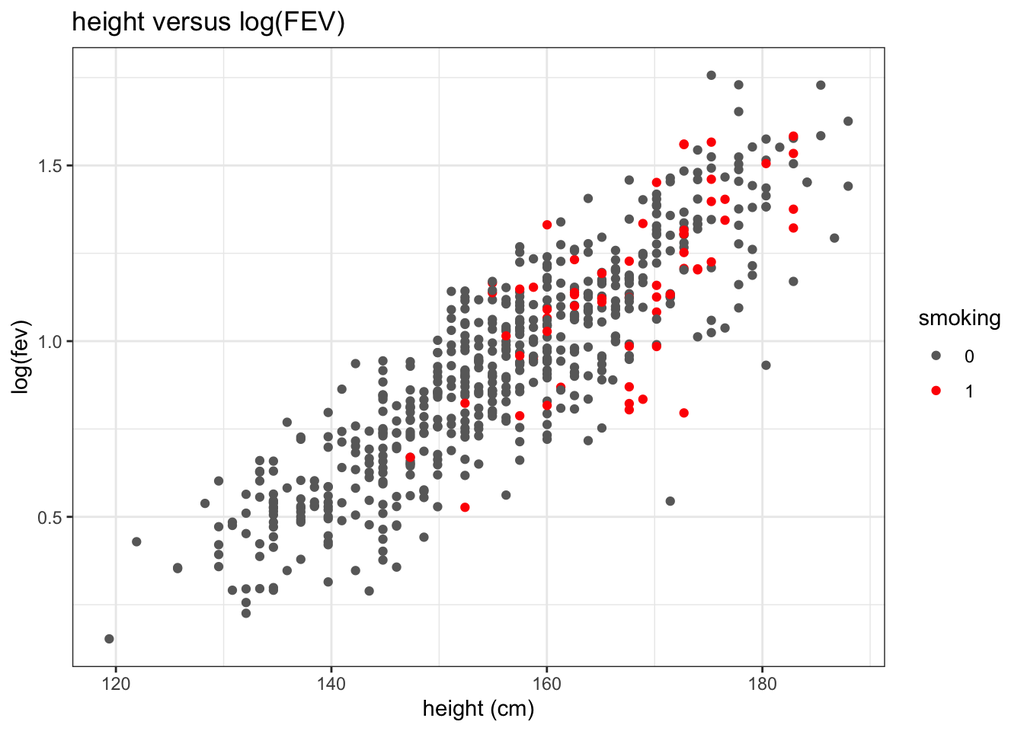

```r
fev %>%
  ggplot(aes(x=height_cm,y=log(fev), col=smoking)) +
  geom_point() +
  scale_color_manual(values=c("dimgrey","red")) +
  theme_bw() +
  ggtitle("height versus log(FEV)") +
  xlab("height (cm)")
```

On the other hand, the relationship between age and the logarithm of the FEV is more quadratic:

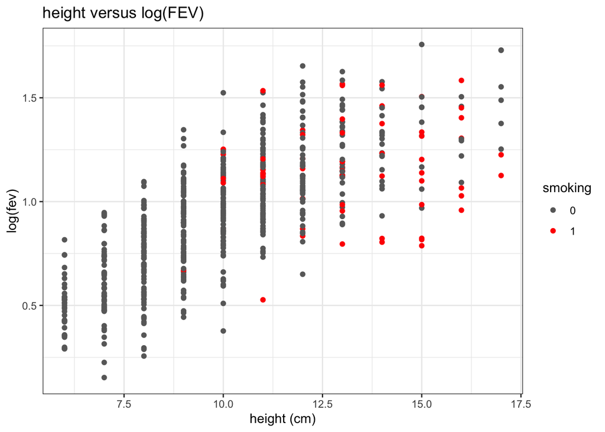

```r
fev %>%
  ggplot(aes(x=age,y=log(fev), col=smoking)) +
  geom_point() +
  scale_color_manual(values=c("dimgrey","red")) +
  theme_bw() +
  ggtitle("height versus log(FEV)") +
  xlab("height (cm)")
```

Remember the “Data_exploration_FEV.Rmd” file? There, we saw that plotting the FEV in function of smoking status only, it appeared that the FEV was higher for smokers. We showed this as follows:

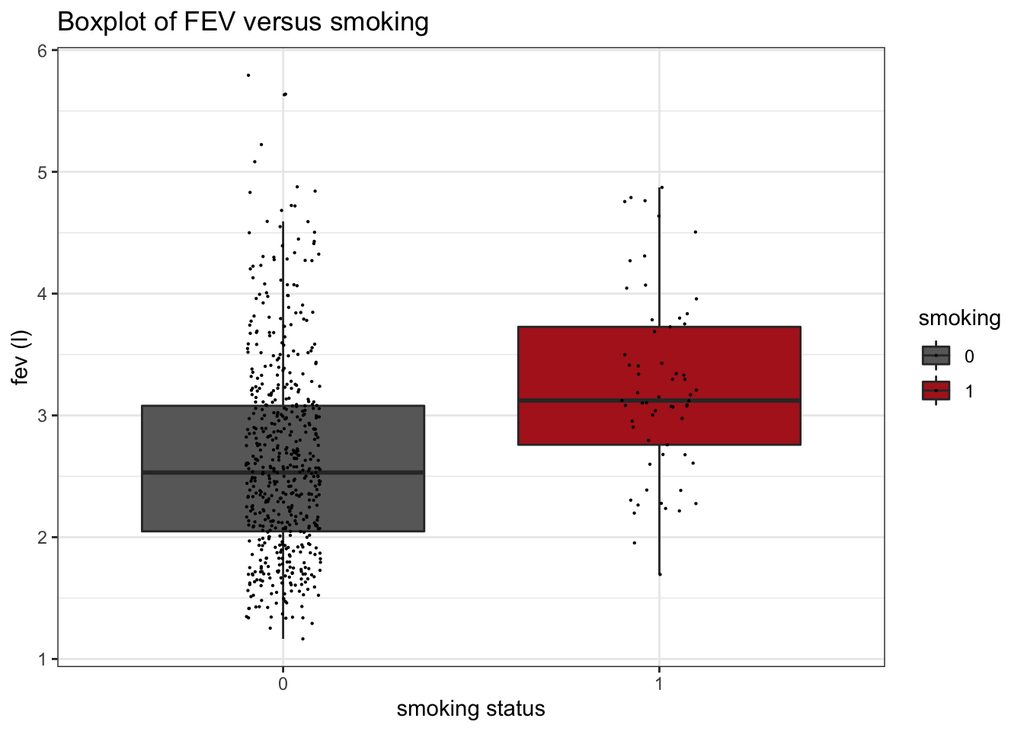

```r
fev %>%
  ggplot(aes(x=smoking,y=fev,fill=smoking)) +
  geom_boxplot(outlier.shape=NA) +
  geom_point(size = 0.1, position = position_jitterdodge()) +
  theme_bw() +
  scale_fill_manual(values=c("dimgrey","firebrick")) +
  ggtitle("Boxplot of FEV versus smoking") +
  ylab("fev (l)") +
  xlab("smoking status")
```

However, if we accounted for a child’s age and/or heigth and/or gender in the visualization, this completely changed the picture.

Let’s again make a nice plot where we make a boxplot of the FEV in function of age (as factor), stratified on gender (facet) and colored based on the smoking status.

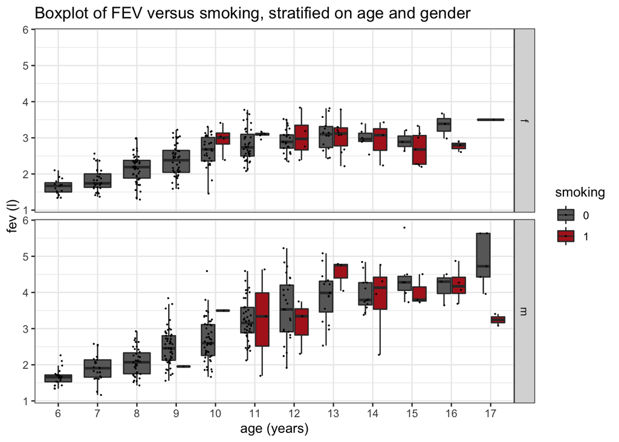

```r
fev %>%
  ggplot(aes(x=as.factor(age),y=fev,fill=smoking)) +
  geom_boxplot(outlier.shape=NA) +
  geom_point(size = 0.1, position = position_jitterdodge()) +
  theme_bw() +
  scale_fill_manual(values=c("dimgrey","firebrick")) +
  ggtitle("Boxplot of FEV versus smoking, stratified on age and gender") +
  ylab("fev (l)") +
  xlab("age (years)") +
  facet_grid(rows = vars(gender))
```

# 6 Analysis

## 6.1 Full model

```r
full_formula <- log(fev)~ age + height_cm + smoking + gender + smoking:age + smoking:height_cm + smoking:gender + age:height_cm + age:gender + height_cm:gender

lm_full <- lm(full_formula, data=fev)

summary(lm_full)
```

```
##
## Call:
## lm(formula = full_formula, data = fev)
##
## Residuals:
##      Min       1Q   Median       3Q      Max
## -0.54574 -0.08702  0.01396  0.09634  0.35404
##
## Coefficients:
##                      Estimate Std. Error t value Pr(>|t|)
## (Intercept)        -1.782e+00  3.055e-01  -5.835 8.84e-09 ***
## age                 3.953e-02  3.179e-02   1.243    0.214
## height_cm           1.538e-02  2.076e-03   7.407 4.44e-13 ***
## smoking1           -1.137e-01  4.670e-01  -0.243    0.808
## genderm            -2.342e-01  1.864e-01  -1.256    0.209
## age:smoking1       -2.158e-02  1.021e-02  -2.113    0.035 *
## height_cm:smoking1  2.056e-03  2.863e-03   0.718    0.473
## smoking1:genderm    2.651e-03  4.939e-02   0.054    0.957
## age:height_cm      -5.835e-05  1.986e-04  -0.294    0.769
## age:genderm        -1.823e-03  7.672e-03  -0.238    0.812
## height_cm:genderm   1.779e-03  1.486e-03   1.197    0.232
## ---
## Signif. codes:  0 '***' 0.001 '**' 0.01 '*' 0.05 '.' 0.1 ' ' 1
##
## Residual standard error: 0.1423 on 595 degrees of freedom
## Multiple R-squared:  0.7846, Adjusted R-squared:  0.781
## F-statistic: 216.7 on 10 and 595 DF,  p-value: < 2.2e-16
```

**Decide on how to communicate the results!**

# [Home](https://gtpb.github.io/PSLS20/)